# Data Basics & Sampling Principles MTH 361 A/B Applied Statistics I Spring 2023

University of Portland

2022-01-23

# R Packages

```r
library(tidyverse)
library(openintro)
```

R packages are groups of R functions, compiled code, and example data. In the R environment, they are saved in the `library` directory. R installs a set of packages by default after installation. More packages will be added later if they are required for a specific purpose. When we launch the R console, just the default packages are available. Other packages that are already installed must be explicitly loaded before they may be utilized by the R application.

Throughout this presentation, we are using the [`county`](https://www.openintro.org/data/index.php?data=county) dataset.

# Loading Datasets

```r
# selecting only 3 rows to display from the county dataframe
county %>%
  slice(1:3)
```

```
## # A tibble: 3 × 15
##   name     state pop2000 pop2010 pop2017 pop_c…¹ poverty homeo…² multi…³ unemp…⁴
##   <chr>    <fct>   <dbl>   <dbl>   <int>   <dbl>   <dbl>   <dbl>   <dbl>   <dbl>
## 1 Autauga… Alab…   43671   54571   55504    1.48    13.7    77.5     7.2    3.86
## 2 Baldwin… Alab…  140415  182265  212628    9.19    11.8    76.7    22.6    3.99
## 3 Barbour… Alab…   29038   27457   25270   -6.22    27.2    68      11.1    5.9
## # … with 5 more variables: metro <fct>, median_edu <fct>,
## #   per_capita_income <dbl>, median_hh_income <int>, smoking_ban <fct>, and
## #   abbreviated variable names ¹pop_change, ²homeownership, ³multi_unit,
## #   ⁴unemployment_rate
```

Examples of variable types.

1. `name` - nominal categorical variable
2. `state` - nominal categorical variable
3. `pop2000` - discrete numerical variable
4. `pop_change` - continuous numerical variable
5. `median_edu` - ordinal categorical variable

# Accessing Rows and Columns

- Using brackets to access **specific indices** of the data frame with the first 3 rows.

```r
# accessing only the 1st 3 rows and 1st 5 columns of the county dataframe
county[1:3,1:5]
```

```
## # A tibble: 3 × 5
##   name           state   pop2000 pop2010 pop2017
##   <chr>          <fct>     <dbl>   <dbl>   <int>
## 1 Autauga County Alabama   43671   54571   55504
## 2 Baldwin County Alabama  140415  182265  212628
## 3 Barbour County Alabama   29038   27457   25270
```

- Using brackets to access **specific column labels** of the data frame with the first 3 rows.

```r
# accessing only the 1st 3 rows and four specific variables
#   from the county dataframe
county[1:3,c("name","state","pop2000","pop2010")]
```

```
## # A tibble: 3 × 4
##   name           state   pop2000 pop2010
##   <chr>          <fct>     <dbl>   <dbl>
## 1 Autauga County Alabama   43671   54571
## 2 Baldwin County Alabama  140415  182265
## 3 Barbour County Alabama   29038   27457
```

# Accessing Entire Columns

- Using the `$` command to access a **specific column label** of the data.

```r
# accessing all rows of the pop2000 variable from the county dataframe
glimpse(county$pop2000)
```

```
##  num [1:2560] 43671 140415 29038 20826 51024 ...
```

- Using brackets to access **entire columns** using **specific column labels**.

```r
# accessing all rows of three specific variables  from the county dataframe
glimpse(county[,c("pop2000","pop2010","pop2017")])
```

```
## Rows: 2,560
## Columns: 3
## $ pop2000 <dbl> 43671, 140415, 29038, 20826, 51024, 11714, 36583, 23988, 39593…
## $ pop2010 <dbl> 54571, 182265, 27457, 22915, 57322, 10914, 34215, 25989, 43643…
## $ pop2017 <int> 55504, 212628, 25270, 22668, 58013, 10309, 33713, 25857, 44067…
```

# Basic Descriptive Statistics

- Using `$` command to **summarize one column**.

```r
# computing basic statistics of the pop2000 variable from the county dataframe
summary(county$pop2000)
```

```
##    Min. 1st Qu.  Median    Mean 3rd Qu.    Max.
##     444   10638   23590   84569   56909 9519338
```

- Using brackets to **summarize multiple columns**.

```r
# computing basic statistics of three specific columns from the county dataframe
summary(county[,c("pop2000","pop2010","pop2017")])
```

```
##     pop2000           pop2010           pop2017
##  Min.   :    444   Min.   :    460   Min.   :     457
##  1st Qu.:  10638   1st Qu.:  10803   1st Qu.:   10653
##  Median :  23590   Median :  24767   Median :   24968
##  Mean   :  84569   Mean   :  93788   Mean   :   99575
##  3rd Qu.:  56909   3rd Qu.:  63126   3rd Qu.:   64113
##  Max.   :9519338   Max.   :9818605   Max.   :10163507
```

- Computing **Mean and Standard Deviation of one column**.

```r
# computing the mean and standard deviation of the pop2000 variable
#   from the county dataframe
mean(county$pop2010)
```

```
## [1] 93788.34
```

```r
sd(county$pop2010)
```

```
## [1] 310609.5
```

# Histograms

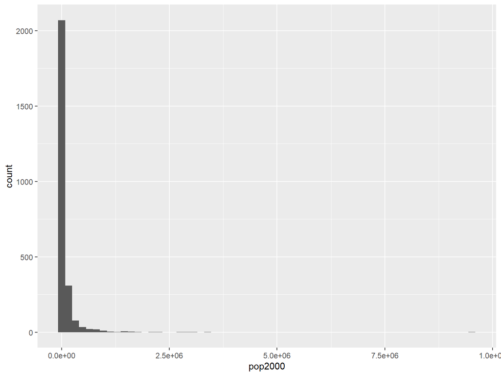

```r
# plot a histogram of the pop2000 variable
#   from the county dataframe
ggplot(data = county, aes(x = pop2000)) + geom_histogram(bins=60)
```

# Scatterplots

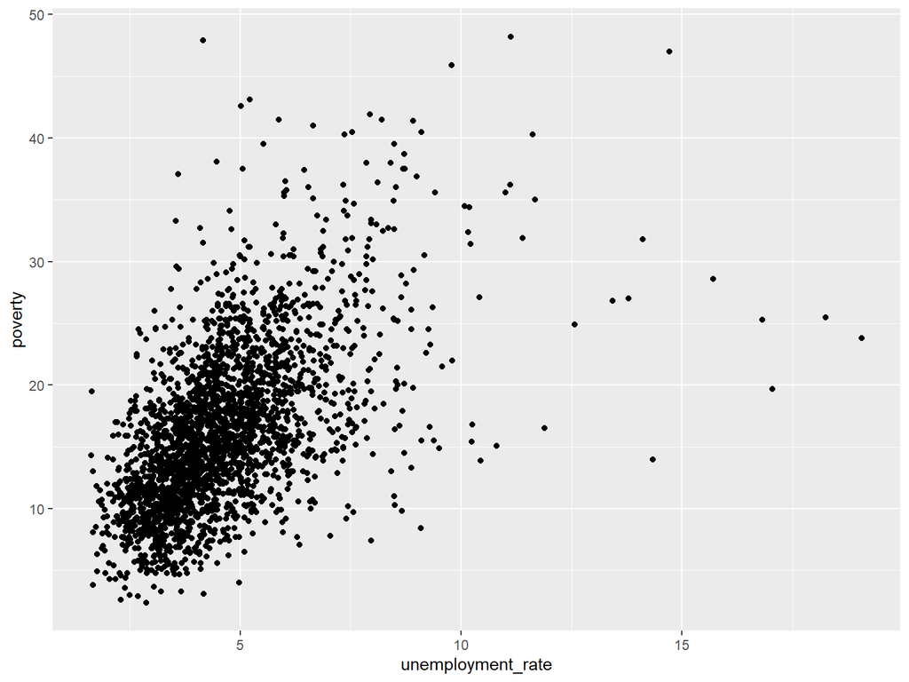

```r
# plot a scatter plot of the variables unemployment_rate and poverty
#   from the the county dataframe
ggplot(data = county, aes(x = unemployment_rate, y = poverty)) + geom_point()
```

# Simple Random Sampling

*Example:* Suppose we want to randomly sample 100 observations (rows) from the data frame.

```r
# number of samples
n <- 100

# pick random row indices from the data frame
#   the replace=FALSE means that we sampling without replacement
rand_index <- sample.int(dim(county)[1],n, replace = FALSE)

# select rows using the random indices
simple_random_sample <- county %>% slice(rand_index)

# take a glimpse of the random sample
glimpse(simple_random_sample)
```

```
## Rows: 100
## Columns: 15
## $ name              <chr> "McKinley County", "Arkansas County", "Gosper County…
## $ state             <fct> New Mexico, Arkansas, Nebraska, Illinois, Illinois, …
## $ pop2000           <dbl> 74798, 20749, 2143, 9590, 21802, 30722, 21802, 21908…
## $ pop2010           <dbl> 71492, 19019, 2044, 8238, 22140, 32062, 24097, 21100…
## $ pop2017           <int> 72564, 17967, 2028, 6315, 21784, 30666, 25429, 21087…
## $ pop_change        <dbl> -0.06, -4.16, 0.55, -12.70, -1.83, -2.35, 1.92, 0.00…
## $ poverty           <dbl> 37.5, 20.7, 5.7, 33.4, 17.8, 30.6, 12.4, 11.1, 15.3,…
## $ homeownership     <dbl> 73.4, 64.4, 76.8, 71.4, 79.5, 61.8, 64.7, 68.7, 81.0…
## $ multi_unit        <dbl> 7.3, 10.9, 1.6, 13.9, 8.0, 8.4, 21.8, 24.3, 3.9, 19.…
## $ unemployment_rate <dbl> 8.69, 3.26, 2.60, 7.96, 5.43, 5.70, 3.32, 2.32, 5.47…
## $ metro             <fct> no, no, no, yes, no, no, no, no, no, no, no, yes, ye…
## $ median_edu        <fct> hs_diploma, hs_diploma, some_college, hs_diploma, hs…
## $ per_capita_income <dbl> 12390.96, 23320.00, 32761.16, 16404.07, 22091.63, 14…
## $ median_hh_income  <int> 30336, 38532, 61769, 31014, 44541, 30866, 49275, 560…
## $ smoking_ban       <fct> none, none, none, none, none, none, none, partial, n…
```

# Stratified Random Sampling

*Example 1:* Suppose we want to sample 50% of observations of each state in the data frame.

```r
strat_sample_frac <- county %>%
                     # group by state (states as strata)
                     group_by(state) %>%
                     # create new column that counts
                     #    the number of observations in each strata
                     mutate(num_rows=n()) %>%
                     # randomly sample 50% of observations in each strata
                     sample_frac(0.50, weight=num_rows) %>%
                     # make data frame ungrouped
                     ungroup()

# take a glimpse of the random sample
glimpse(strat_sample_frac)
```

```
## Rows: 1,278
## Columns: 16
## $ name              <chr> "Marengo County", "Conecuh County", "Bibb County", "…
## $ state             <fct> Alabama, Alabama, Alabama, Alabama, Alabama, Alabama…
## $ pop2000           <dbl> 22539, 14089, 20826, 140415, 11714, 65676, 15922, 14…
## $ pop2010           <dbl> 21027, 13228, 22915, 182265, 10914, 82782, 13859, 13…
## $ pop2017           <int> 19375, 12469, 22668, 212628, 10309, 94402, 12945, 12…
## $ pop_change        <dbl> -3.63, -3.40, 0.73, 9.19, -2.28, 6.19, -3.37, -5.15,…
## $ poverty           <dbl> 25.6, 26.4, 15.2, 11.8, 28.5, 14.8, 22.3, 36.0, 17.6…
## $ homeownership     <dbl> 73.5, 81.6, 82.9, 76.7, 76.9, 77.1, 85.6, 68.3, 66.8…
## $ multi_unit        <dbl> 8.3, 6.0, 6.6, 22.6, 9.9, 9.4, 3.9, 14.5, 24.0, 11.1…
## $ unemployment_rate <dbl> 5.65, 6.14, 4.39, 3.99, 4.93, 3.98, 6.39, 6.54, 4.24…
## $ metro             <fct> no, no, yes, yes, no, yes, no, no, yes, no, yes, yes…
## $ median_edu        <fct> hs_diploma, hs_diploma, hs_diploma, some_college, hs…
## $ per_capita_income <dbl> 20738.37, 14814.23, 20572.05, 27779.85, 15444.16, 25…
## $ median_hh_income  <int> 32255, 30434, 43404, 52562, 29655, 52831, 32122, 216…
## $ smoking_ban       <fct> none, none, none, none, none, none, none, partial, n…
## $ num_rows          <int> 61, 61, 61, 61, 61, 61, 61, 61, 61, 61, 61, 61, 61, …
```

Now, let’s check if the code did it right.

```r
# checking number of total observations
nto <- dim(county %>% filter(state == "California"))[1]
# checking number of sample observations
nso <- dim(strat_sample_frac %>% filter(state == "California"))[1]

# ratio
nso/nto # the ratio should be 0.50
```

```
## [1] 0.5
```

*Example 2:* Suppose we want to sample exactly 100 observations in each level of the `metro` variable.

```r
stratified_sample <- county %>%
                     # group by metro (metro - yes or no - as strata)
                     group_by(metro) %>%
                     # randomly sample 100 observations in each strata
                     sample_n(100) %>%
                     # make data frame ungrouped
                     ungroup()

# take a glimpse of the random sample
glimpse(stratified_sample)
```

```
## Rows: 200
## Columns: 15
## $ name              <chr> "Marion County", "Daviess County", "Kit Carson Count…
## $ state             <fct> West Virginia, Missouri, Colorado, Oregon, Pennsylva…
## $ pop2000           <dbl> 56598, 8016, 8011, 24530, 4946, 5180, 37710, 16670, …
## $ pop2010           <dbl> 56418, 8433, 8270, 25748, 7716, 4881, 36743, 17601, …
## $ pop2017           <int> 56337, 8361, 7158, 26222, 7297, 4551, 32925, 17644, …
## $ pop_change        <dbl> -0.55, 0.72, -13.07, 2.83, -3.15, -3.11, -8.34, 0.20…
## $ poverty           <dbl> 16.1, 13.2, 11.5, 17.4, 14.1, 20.3, 22.5, 11.2, 11.3…
## $ homeownership     <dbl> 75.1, 74.7, 69.3, 66.0, 85.8, 83.6, 72.8, 72.3, 79.0…
## $ multi_unit        <dbl> 13.0, 7.4, 10.7, 17.5, 1.6, 0.8, 8.9, 13.1, 12.4, 5.…
## $ unemployment_rate <dbl> 5.22, 3.32, 1.82, 5.29, 6.71, 7.88, 7.50, 3.69, 3.75…
## $ metro             <fct> no, no, no, no, no, no, no, no, no, no, no, no, no, …
## $ median_edu        <fct> hs_diploma, hs_diploma, hs_diploma, some_college, hs…
## $ per_capita_income <dbl> 25365.84, 21991.63, 28366.67, 26828.81, 22877.66, 13…
## $ median_hh_income  <int> 48158, 45707, 45881, 46228, 37106, 26644, 37859, 465…
## $ smoking_ban       <fct> none, none, partial, none, none, partial, none, none…
```

# Clustered Random Sampling

*Example:* Suppose we consider each state as a cluster, and we randomly sample 10 clusters.

```r
# number of clusters to randomly sample
n_clusters <- 10

# get list of states
states <- levels(county$state)

# sample the states
states_sample <- sample(states,n_clusters)

# get the rows with corresponding states that are sampled.
cluster_sample <- county %>% filter(state==states_sample)

# take a glimpse of the random sample
glimpse(cluster_sample)
```

```
## Rows: 45
## Columns: 15
## $ name              <chr> "Clark County", "Fulton County", "Kendall County", "…
## $ state             <fct> Illinois, Illinois, Illinois, Illinois, Illinois, Ma…
## $ pop2000           <dbl> 17008, 38250, 54544, 13180, 256082, 723419, 9862, 45…
## $ pop2010           <dbl> 16335, 37069, 114736, 12640, 270056, 743159, 9601, 4…
## $ pop2017           <int> 15767, 35110, 126218, 11730, 262479, 785205, 9121, 4…
## $ pop_change        <dbl> -2.04, -3.34, 5.53, -3.23, -1.60, 2.70, -3.29, -0.33…
## $ poverty           <dbl> 14.3, 15.5, 5.6, 10.3, 17.0, 10.9, 13.0, 15.9, 10.7,…
## $ homeownership     <dbl> 77.1, 78.4, 85.8, 82.0, 67.7, 65.4, 81.7, 80.6, 76.4…
## $ multi_unit        <dbl> 6.2, 10.1, 8.8, 7.6, 20.6, 42.7, 7.9, 8.3, 18.7, 6.3…
## $ unemployment_rate <dbl> 4.78, 6.26, 4.48, 5.30, 4.92, 3.78, 8.42, 4.74, 6.64…
## $ metro             <fct> no, no, yes, yes, yes, yes, no, no, no, no, yes, yes…
## $ median_edu        <fct> some_college, some_college, some_college, some_colle…
## $ per_capita_income <dbl> 28890.04, 25657.45, 32930.29, 28900.42, 28111.86, 38…
## $ median_hh_income  <int> 52068, 48599, 89860, 55173, 51103, 73533, 42647, 481…
## $ smoking_ban       <fct> partial, none, none, partial, none, partial, partial…
```